# How to circlize

Brian J. Knaus

2023, January 05

## Introduction

Circular plots have become a popular way to visualize genomic data. This may be because the first genomes that were sequenced were bacterial genomes, which are circular. Researchers of eukaryotic genomes have continued this style of graphic. This is perhaps because it facilitates the comparison of chromosomes on the outside of the circle with bands that extend through the middle of the plot to indicate regions of synteny. Early versions of this style of plot were created with the software ‘Circos’ (http://circos.ca/), in a system that draws on the organization present in Unix filesystems. More recently, this plot style has been facilitated by the R package ‘circlize’ (https://CRAN.R-project.org/package=circlize). This package is accompanied by a book (https://jokergoo.github.io/circlize_book/book/) to describe it’s use. Here we’ll use the **Cannabis sativa** CBDRx assembly (https://www.ncbi.nlm.nih.gov/data-hub/genome/GCF_900626175.2/) as an example of creating circular plots in R.

## A simple plot

A basic plot can be created with ‘BED’ format data. This format is described online (https://genome.ucsc.edu/FAQ/FAQformat.html#format1, https://uswest.ensembl.org/info/website/upload/bed.html, https://en.wikipedia.org/wiki/BED_(file_format) ). This is tabular data where the first three columns indicate each chromosome name, start, and end coordinates. Subsequent columns are optional. We begin by summarizing the genomic FASTA sequence obtained from NCBI with a script I’ve created (https://github.com/knausb/fasta2nuccomp). This results in a table of data that we can read in to R and convert to ‘BED’ format.

```r
nucs <- read.csv("./GCF_900626175.2_cs10_genomic_nuccomp.csv")
nucs <- nucs[1:10, ]

nucs$GC <- rowSums( nucs[, c("C", "c", "G", "g")] )/rowSums( nucs[, c("A", "a", "C", "c", "G", "g", "T", "t")] )
nucs$GC <- nucs$GC * 100


nucs[1:3, 1:8]
```

```
##            Id    Length        a        A       c       C       g       G
## 1 NC_044371.1 101209240 12762692 11748277 4717714 7349355 4737281 7366441
## 2 NC_044375.1  96346938 15648113  9880538 6495082 6457816 6501151 6462266
## 3 NC_044372.1  94670641 15834625  9810980 6494817 6342764 6541912 6351808
```

```r
nrow(nucs)
```

```
## [1] 10
```

```r
myBed <- data.frame( chrom = nucs$Id, chromStart = 1, chromEnd = nucs$Length, gc = nucs$GC)

myBed$gcs <- myBed$gc - min(myBed$gc)
myBed$gcs <- myBed$gcs/max(myBed$gcs)
myBed$gcs <- myBed$gcs * 100
myBed$gcs <- as.integer(myBed$gcs)
myBed$gcs[ myBed$gcs == 0 ] <- 1
myBed$cols <- viridisLite::magma(n=100, alpha = 0.4, begin = 0.2, end = 1.0)[ myBed$gcs ]
#nSeq <- 10
#myBed <- data.frame( chrom = nucs$Id[1:nSeq], chromStart = 1, chromEnd = nucs$Length[1:nSeq])
# apply(myBed , MARGIN = 2, class)
head(myBed)
```

```
##         chrom chromStart  chromEnd       gc gcs      cols
## 1 NC_044371.1          1 101209240 33.02160   1 #3B0F7066
## 2 NC_044375.1          1  96346938 33.66868  80 #FEB27A66
## 3 NC_044372.1          1  94670641 33.38452  45 #CD407166
## 4 NC_044373.1          1  91913879 33.10673  10 #5A167E66
## 5 NC_044374.1          1  88181582 33.51140  61 #F4685C66
## 6 NC_044377.1          1  79335105 33.50048  59 #F2615D66
```

Genomic assemblies currently contain sequences that are close to full chromosome assemblies, as well as numerous shorter sequences we refer to as ‘unplaced contigs.’ The hemp genome is expected to contain 10 chromosomes, so we’ve subset the data to these sequences. Note that the BED format does not include a header line. In R, it is frequently useful to use a header, so we’ve created one for our data.frame.

We now load the R package ‘circlize’. This package includes a verbose start up message. The book shows us that we can suppress this message once we’ve read it.

```r
#library(circlize)
suppressPackageStartupMessages(library(circlize))
```

We can now create our plot. Each plot begins with the function `circos.genomicInitialize()` and ends with `circos.clear()`. The function `circos.genomicInitialize()` includes the BED-like data.frame we created and named ‘myBed’ as well as other parameters to control the appearance of the plot. Note that ‘circlize’ uses the ‘base’ graphics engines as opposed to other R graphics engines (e.g., ggplot2 or lattice). Parameters to help control the appearance of base R graphics can be found in the `?par` manual page. Here we create our simple plot and add some text to it’s center.

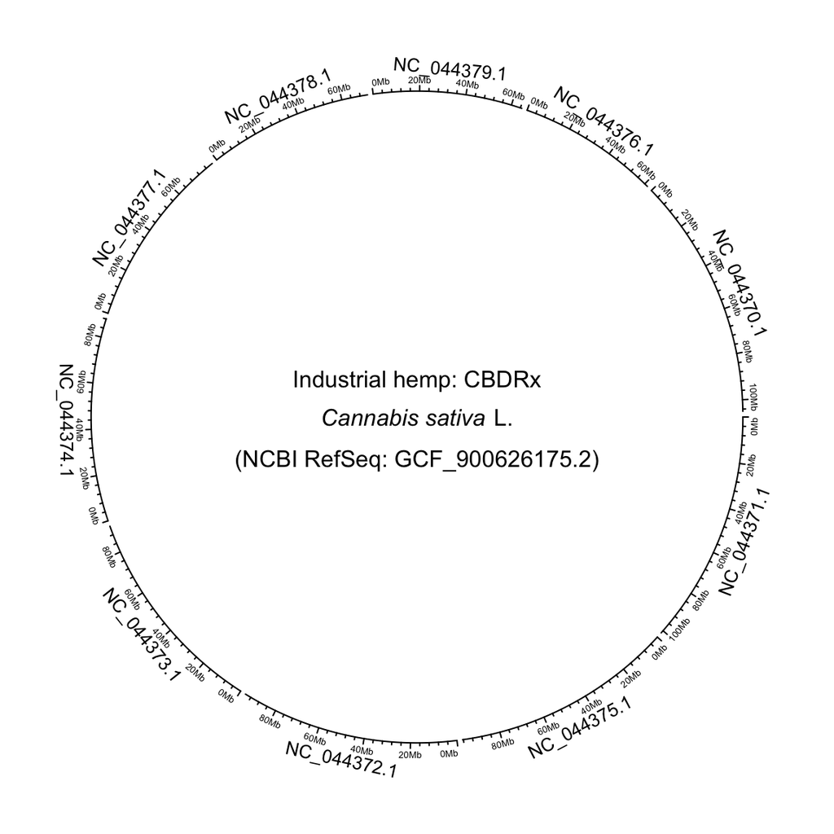

**Figure 1.** A simple circular plot.

```r
circos.genomicInitialize(
  data = myBed,
  axis.labels.cex =  0.4 * par("cex"),
  labels.cex = 0.8 * par("cex")
)

text(x = 0, y = 0.1, labels = "Industrial hemp: CBDRx")
text(x = 0, y = 0, labels = expression(paste(italic("Cannabis sativa"), " L.")))
text(x = 0, y = -0.12, labels = "(NCBI RefSeq: GCF_900626175.2)")
```

```r
circos.clear()
```

## Tracks and sectors

A plot in ‘circlize’ may include ‘tracks’ and ‘sectors’. The **tracks** form concentric circles beginning at the outside of the circle and extend in towards the center of the plot. In the context of our genomic plot, each track represents the genome (all 10 chromosomes). Each track consists of **sectors** that each represent a plot or panel for each chromosome. Within each panel we have an x and y coordinate system for plotting information. We can also add `circos.par( start.degree = 90 )` to start thre plot at the top of the plot (12 o’clock). We can now add to our first plot by adding two tracks that include 10 sectors.

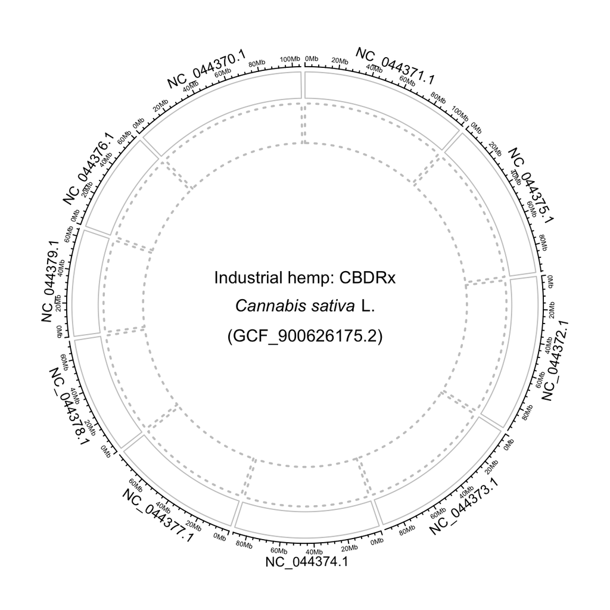

**Figure 2.** A simple circular plot including tracks and sectors.

```r
circos.par( start.degree = 90 )
circos.genomicInitialize(
  data = myBed,
  axis.labels.cex =  0.4 * par("cex"),
  labels.cex = 0.8 * par("cex")
)

text(x = 0, y = 0.1, labels = "Industrial hemp: CBDRx")
text(x = 0, y = 0, labels = expression(paste(italic("Cannabis sativa"), " L.")))
text(x = 0, y = -0.12, labels = "(GCF_900626175.2)")

circos.track(ylim = c(0, 1),
    bg.col = NA,
    bg.border = "#00000044",
    track.height = 0.1)

circos.track(ylim = c(0, 1),
    bg.col = NA,
    bg.border = "#00000044",
    track.height = 0.15, bg.lty = 3, bg.lwd = 2)
```

```r
circos.clear()
```

## GFF data

Genomic annotations (e.g., genes, transcripts, exons, etc.) are frequently provided in the GFF format (https://en.wikipedia.org/wiki/General_feature_format). This can be seen as tabular data with a header region at the top (prefixed with # signs) and nine columns where the first eight are defined and the last column is intended to hold ‘other’ data in a ‘key and value’ format where multiple ‘key and value’ pairs are delimited by a semicolon (‘;’). For our purposes a GFF file can be read in with R’s standard read functions, with a little modification. A GFF file is tab delimited, we specify this by setting `sep = "\t"`. The annotations may include content such as `5' UTR`. The R read functions will tend to interpret the ‘prime’ as an unmatched single quote. We can manage this by setting `quote = "\""` so only double quotes will be interpreted as quotes.

Our data includes chromosome scale sequences, as well as unplaced contigs and a mitochondrion. The chromosomal sequences begin with “NC_04”, we can use this to isolate the sequences we’re interested in.

```r
gff <- read.table("GCF_900626175.2_cs10_genomic.gff.gz", sep = "\t", quote = "\"")
colnames(gff) <- c("seqid","source","type","start","end","score","strand","phase","attributes")
gff[1:3, 1:8]
```

```
##         seqid source    type start       end score strand phase
## 1 NC_044371.1 RefSeq  region     1 101209240     .      +     .
## 2 NC_044371.1 Gnomon    gene  3273      3552     .      -     .
## 3 NC_044371.1 Gnomon lnc_RNA  3273      3552     .      -     .
```

```r
# Isolate chromosomal sequences.
gff <- gff[grep("^NC_04", gff$seqid), ]

# Isolate 'genes.'
genes <- gff[grep("gene", gff$type), ]
nrow(genes)
```

```
## [1] 30695
```

```r
# Isolate 'rRNA'.
rrna <- gff[grep("S rRNA", gff$attributes), ]
nrow(rrna)
```

```
## [1] 434
```

The 9th column, or the attributes, of GFF data consists of ‘key value’ pairs delimited by a semicolon. We can split this string on the delimiter (‘;’) and use grep to return just the strings with the ‘product’ key. We can then use this to isolate terpenes, or other products (keywords) we may be interested in.

```r
my_products <- lapply(strsplit(gff$attributes, split = ";"), function(x){ grep("product=", x, value = TRUE) })
my_products <- unlist(my_products)
my_products <- sub("product=", "", my_products)

#sort(table(my_products), decreasing = TRUE)[1:10]
#
sort(table(grep("[Tt]erpene", my_products, value = TRUE)), decreasing = TRUE)[1:6]
```

```
##
## probable monoterpene synthase MTS1%2C chloroplastic
##                                                  68
##                                 terpene synthase 10
##                                                  30
##   terpene synthase 10-like%2C transcript variant X2
##                                                  17
##   terpene synthase 10-like%2C transcript variant X1
##                                                  16
##                        probable terpene synthase 11
##                                                  15
##                         probable terpene synthase 9
##                                                  15
```

```r
terps <- gff[grep("[Tt]erpene", gff$attributes), ]
nrow(terps)
```

```
## [1] 223
```

## Gene abundance tracks

Now that we’ve gathered some information about our assembly, we can use it in our graphic. We can use the gene start positions to create histograms. The background for the histogram cells can be colored by GC content. A track for rRNA and terpenes represented as points can demonstrate where these features are found. Another track with rectangles may be useful for larger features. Lastly, we can include labels for select features and links among features on different chromosomes.

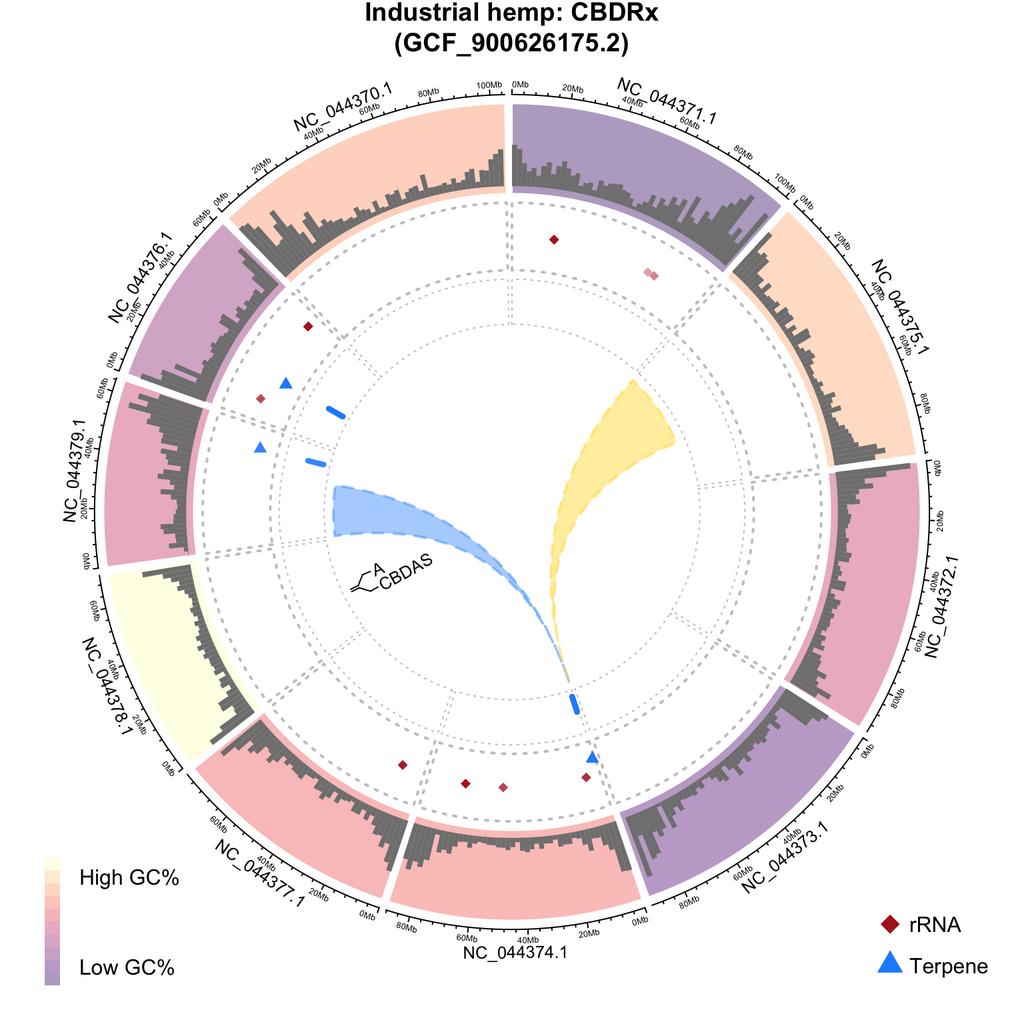

**Figure 3.** A simple circular plot including tracks and sectors.

```r
#png(filename = "gdplot.png", width = 18, height = 18, units = "cm", res = 300)

# circos.clear()

circos.par( start.degree = 90 )

circos.genomicInitialize(
  data = myBed,
  axis.labels.cex =  0.4 * par("cex"),
  labels.cex = 0.8 * par("cex")
)

circos.trackHist(
  sectors = genes$seqid,
#  sectors = as.factor(genes$seqid),
  x = genes$start,
  #border = "#FFFFFF",
  bg.border = "#FFFFFF",
  bg.col = myBed$cols,
  #col = c("#FF0000", "#00FF00"),
  #col = "#C0C0C0",
  col = "#808080",
  border = NA,
  breaks = seq(1, 1e9, by = 2e6) )

circos.track(ylim = c(0, 1),
    bg.col = NA,
    bg.border = "#00000044",
    track.height = 0.15, bg.lty = 3, bg.lwd = 2)

circos.trackPoints(
  sectors = as.factor(rrna$seqid),
  x = rrna$start,
  y = rep(0.5, times = nrow(rrna)),
  #y = genes$start,
  #pch = "|",
  pch = 18,
  col = "#B2222211"
)

circos.trackPoints(
  sectors = as.factor(terps$seqid),
  x = terps$start,
  y = rep(0.2, times = nrow(terps)),
  #y = genes$start,
  #pch = "|",
  pch = 17,
  cex = 1,
  col = "#1E90FF11"
)

circos.track(ylim = c(0, 1),
    bg.col = NA,
    bg.border = "#00000044",
    track.height = 0.10, bg.lty = 3, bg.lwd = 1)

for( i in unique(terps$seqid) ){
  tmp <- terps[terps$seqid == i, ]

  circos.rect(
    xleft = tmp$start,
    ybottom = -0.0,
    xright = tmp$end,
    ytop = 0.5,
    sector.index = i,
    col = "#1E90FF11",
    border = "#1E90FF11",
    lwd = 4
  )
}

circos.link("NC_044374.1", 0,
            "NC_044379.1", c(1e3,4e7),
            col = "#1E90FF66",
            #border = "black",
            lwd = 2, lty = 2)

circos.link("NC_044374.1", 0,
            "NC_044375.1", c(1e3,6e7),
            col = "#FFD70066",
            #border = "black",
            lwd = 2, lty = 2)

circos.labels(c("NC_044378.1", "NC_044378.1"),
              x = c(30.1e6, 28.12e6), labels = c("A", "CBDAS"),
    side = "inside")

myLeg <- rep("", times = 10)
myLeg[c(2, 9)] <- c("High GC%", "Low GC%")

legend('bottomleft',
       legend = myLeg,
       fill = viridisLite::magma(n=10, alpha = 0.4, begin = 1.0, end = 0.2),
       border = NA,
       pt.cex = 2,
       bty = "n", y.intersp = 0.5)

legend('bottomright',
       legend = c("rRNA", "Terpene"),
       col = c("#B22222", "#1E90FF"),
       border = NA,
       pch = c(18, 17),
       pt.cex = 2,
       bty = "n",
       y.intersp = 1.6)


title( main = "Industrial hemp: CBDRx\n(GCF_900626175.2)", line = -1 )
```

```r
circos.clear()

#dev.off()
```

## Adding more…

```r
#png(filename = "gdplot.png", width = 18, height = 18, units = "cm", res = 300)

# circos.clear()

circos.par( start.degree = 90 )
#circos.par(gap.after = c(2, 2, 2, 2, 10))
circos.par(gap.after = c(rep(2, times = 9), 10))

circos.genomicInitialize(
  data = myBed,
  axis.labels.cex =  0.4 * par("cex"),
  labels.cex = 0.8 * par("cex")
)

# text(x = 0, y = 0.1, labels = "Industrial hemp: CBDRx")
# text(x = 0, y = 0, labels = expression(paste(italic("Cannabis sativa"), " L.")))
# text(x = 0, y = -0.12, labels = "(GCF_900626175.2)")

# circos.track(ylim = c(0, 1),
#     bg.col = NA,
#     bg.border = "#00000044",
#     track.height = 0.1)

circos.trackHist(
  sectors = as.factor(genes$seqid),
  x = genes$start,
  #border = "#FFFFFF",
  bg.border = "#FFFFFF",
  bg.col = myBed$cols,
  #col = c("#FF0000", "#00FF00"),
  #col = "#C0C0C0",
  col = "#808080",
  border = NA,
  breaks = seq(1, 1e9, by = 2e6) )


circos.track(ylim = c(0, 1),
    bg.col = NA,
    bg.border = "#00000044",
    track.height = 0.15, bg.lty = 3, bg.lwd = 2)

circos.trackPoints(
  sectors = as.factor(rrna$seqid),
  x = rrna$start,
  y = rep(0.5, times = nrow(rrna)),
  #y = genes$start,
  #pch = "|",
  pch = 18,
  col = "#B2222211"
)

circos.trackPoints(
  sectors = as.factor(terps$seqid),
  x = terps$start,
  y = rep(0.2, times = nrow(terps)),
  #y = genes$start,
  #pch = "|",
  pch = 17,
  col = "#1E90FF11"
)

circos.track(ylim = c(0, 1),
    bg.col = NA,
    bg.border = "#00000044",
    track.height = 0.10, bg.lty = 3, bg.lwd = 1)

# circos.trackLines(
#   sectors = as.factor(terps$seqid),
#   x = terps$start,
#   y = terps$end,
#   #y = rep(0.2, times = nrow(terps)),
#   #y = genes$start,
#   #pch = "|",
# #  pch = 17,
#   col = "#1E90FF11"
# )


for( i in unique(terps$seqid) ){
  tmp <- terps[terps$seqid == i, ]

  circos.rect(
    xleft = tmp$start,
    ybottom = -0.0,
    xright = tmp$end,
    ytop = 0.5,
    sector.index = i,
    col = "#1E90FF11",
    border = "#1E90FF11",
    lwd = 4
  )
}

circos.link("NC_044374.1", 0,
            "NC_044379.1", c(1e3,4e7),
            col = "#1E90FF66",
            #border = "black",
            lwd = 2, lty = 2)

circos.link("NC_044374.1", 0,
            "NC_044375.1", c(1e3,6e7),
            col = "#FFD70066",
            #border = "black",
            lwd = 2, lty = 2)

circos.labels(c("NC_044378.1", "NC_044378.1"),
              x = c(30.1e6, 28.12e6), labels = c("A", "CBDAS"),
    side = "inside")

# circos.link("NC_044374.1", 0, "NC_044379.1", c(1e3,4e7),
#             col = "green", border = "black", lwd = 2, lty = 2)

#circos.text( x = 1, y = 200.5, labels = "Hi", sector.index = "NC_044371.1", track.index = 2)
#circos.text( x = 115e6, y = 200.5, labels = "GC", sector.index = "NC_044370.1", track.index = 2)
circos.text( x = 115e6, y = 0.5, labels = "Gene", sector.index = "NC_044370.1", track.index = 3)
```

```
## Note: 1 point is out of plotting region in sector 'NC_044370.1', track
## '3'.
```

```r
circos.text( x = 115e6, y = 0.5, labels = "Line", sector.index = "NC_044370.1", track.index = 4)
```

```
## Note: 1 point is out of plotting region in sector 'NC_044370.1', track
## '4'.
```

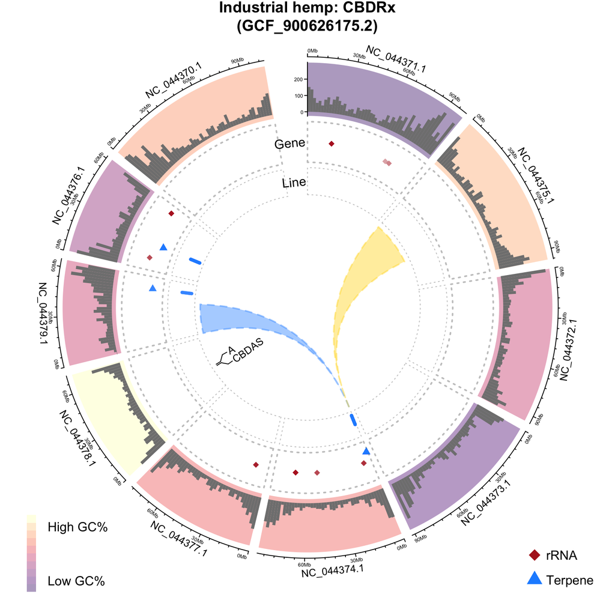

**Figure 4.** A simple circular plot including tracks and sectors.

```r
#circos.yaxis( side = "right", sector.index =  "NC_044370.1", track.index = 2, labels.cex = 0.4)
circos.yaxis( side = "left",
              at = seq(0, 300, by = 100),
              sector.index =  "NC_044371.1", track.index = 2, labels.cex = 0.4)

myLeg <- rep("", times = 10)
myLeg[c(2, 9)] <- c("High GC%", "Low GC%")

legend('bottomleft',
       #legend = c("T1", "", "", "T2"),
       #legend = c("High GC", rep("", times = 8), "Low GC"),
       legend = myLeg,
       #fill = myBed$cols,
       fill = viridisLite::magma(n=10, alpha = 0.4, begin = 1.0, end = 0.2),
       #fill = viridisLite::magma(n=10, alpha = 0.4, begin = 0.2, end = 1.0),
       border = NA,
       bty = "n", y.intersp = 0.5)

legend('bottomright',
       legend = c("rRNA", "Terpene"),
       col = c("#B22222", "#1E90FF"),
       #fill = c("#B22222", "#1E90FF"),
       #col = c("#B2222211", "#1E90FF11"),
       border = NA,
       pch = c(18, 17),
       pt.cex = 2,
       bty = "n",
       y.intersp = 1.6)


title( main = "Industrial hemp: CBDRx\n(GCF_900626175.2)", line = -1 )
```

```r
circos.clear()

#dev.off()
```

## Read in data

```r
#cann <- read.table("../cann_motif_CBDRx_blastn_b2g.gff", sep = "\t")
cann <- read.table("./cann_motif_CBDRx_blastn_b2g.gff", sep = "\t")
colnames(cann)[c(1, 4, 5)] <- c("name", "start", "end")
cann[1:3, 1:8]
```

```
##          name    V2    V3    start      end        V6 V7 V8
## 1 NC_044378.1 blast match 25983536 25983733 5.90e-100  +  .
## 2 NC_044378.1 blast match 26046973 26047170 5.90e-100  +  .
## 3 NC_044378.1 blast match 25823394 25823591  2.74e-98  +  .
```

```r
nSeq <- 10
myBed <- data.frame( chrom = nucs$Id[1:nSeq], chromStart = 1, chromEnd = nucs$Length[1:nSeq])
apply(myBed , MARGIN = 2, class)
```

```
##       chrom  chromStart    chromEnd
## "character" "character" "character"
```

## Organize data

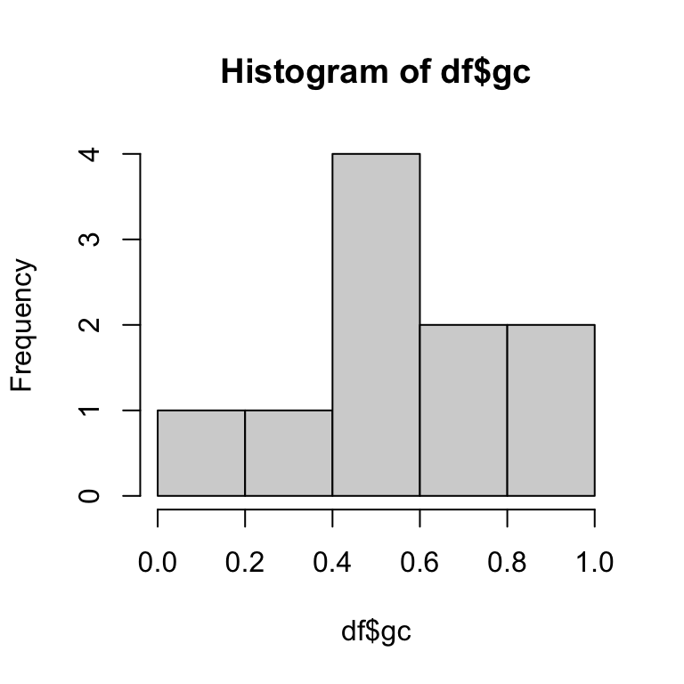

```r
df <- data.frame(name = nucs$Id, start = 1, end = nucs$Length)

#df <- df[-17,]
#sub("ref", "", df$name)
# df$name <- sub("ref\\|", "", df$name)
# df$name <- sub("\\|", "", df$name)
df$col <- "#B2222240"
df$col[4] <- "#9400D3"
df$col[9] <- "#40E0D040"

#df$gc <- (nucs$G[-17] + nucs$C[-17])/nucs$Length[-17]
df$gc <- (nucs$G + nucs$g + nucs$C + nucs$c)/nucs$Length
df$gc <- df$gc - min(df$gc)
df$gc <- df$gc/max(df$gc)
hist(df$gc)
```

```r
df$col2 <- rgb(0, df$gc, 0, 0.4, names = NULL, maxColorValue = 1)

df[1:3, ]
```

```
##          name start       end       col        gc      col2
## 1 NC_044371.1     1 101209240 #B2222240 0.0000000 #00000066
## 2 NC_044375.1     1  96346938 #B2222240 0.3979356 #00650066
## 3 NC_044372.1     1  94670641 #B2222240 0.4349811 #006F0066
```

## Plot graphic

```r
# png(filename = "myplot.png", width = 20, height = 20,
#    units = "cm", res = 300 )

#circos.par(start.degree = 0)
#circos.par(start.degree = 90)
#circos.par(start.degree = 180)

circos.genomicInitialize( data = df )

# circos.track(ylim = c(0, 1),
#     bg.col = c("#FF000040", "#00FF0040", "#0000FF40"),
#     bg.border = NA, track.height = 0.05)

# circos.track(ylim = c(0, 1),
#     bg.col = rep(c("#B2222240", "#40E0D040", "#9400D3"), times = nrow(df)),
#     bg.border = NA, track.height = 0.15)

circos.track(ylim = c(-10, 4),
    bg.col = df$col2,
    bg.border = NA, track.height = 0.15)

#my_chrom <- "NC_001147"
my_chrom <- df$name[2]
circos.points(
  x = seq(1, df$end[df$name == my_chrom], length.out = 100),
  y = seq(0, 1, length.out = 100),
  sector.index = my_chrom,
  pch = 20, cex = 0.4
  )

my_chrom <- df$name[3]
circos.points(
  x = seq(1, df$end[df$name == my_chrom], length.out = 100),
  y = seq(0, 20, length.out = 100),
  sector.index = my_chrom,
  pch = 20, cex = 0.4
  )
```

[output not shown]

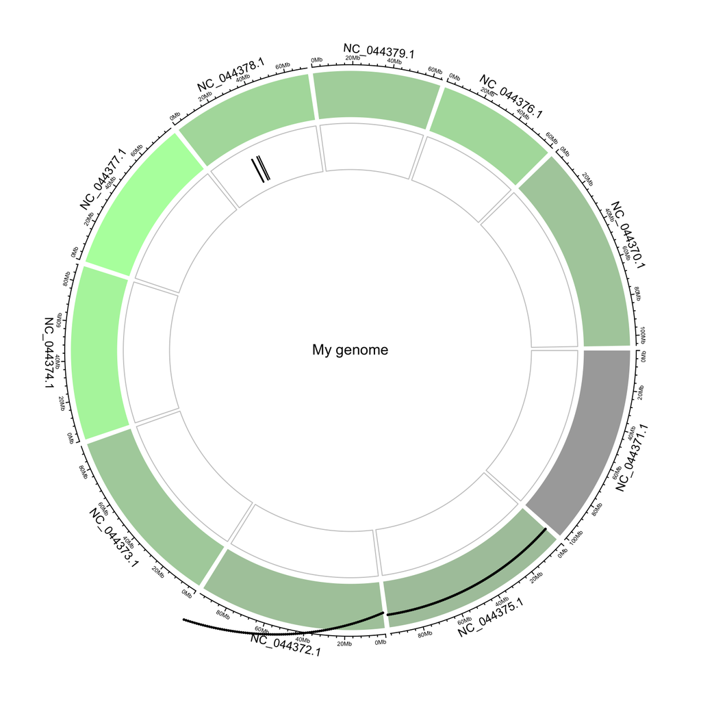

```r
circos.track(ylim = c(0, 1),
    bg.col = NA,
    bg.border = "#00000044", track.height = 0.15)

circos.rect(xleft = cann$start, ybottom = 0.1,
            xright = cann$end, ytop = 0.8,
            sector.index = cann$name[1])


# circos.barplot(value = seq(0, 1, length.out = 10),
#                pos = seq(1, 1e6, length.out = 10) - 0.5,
#                col = 1:10)

# circos.track(ylim = c(0, 255),
#     bg.col = df$col2,
#     bg.border = NA, track.height = 0.15)

text(x = 0, y = 0, "My genome")
```

```r
#axis(side = 1)
#axis(side = 2)

circos.clear()

# dev.off()
```

```r
st99 <- Sys.time()
st99 - st1
```

```
## Time difference of 19.86728 secs
```